# Project 1 Write-up

Minh Nhat “William” Pham

2025-03-06

## Introduction

### Data Import

This project shall utilise the data set *Predict Students’ Dropout and Academic Success* available on UC Irvine’s Machine Learning Repository. Information on the dataset can be found [here](https://archive.ics.uci.edu/dataset/697/predict+students+dropout+and+academic+success).

```r
StudentDataset <- read.csv("../Project/Predict Students Dropout and Academic Success.csv",
                           sep=";", check.names = FALSE)
```

### Data Cleaning

Raw data before cleaning.

```r
str(StudentDataset)
```

```
## 'data.frame':    4424 obs. of  37 variables:
##  $ Marital status                                : int  1 1 1 1 2 2 1 1 1 1 ...
##  $ Application mode                              : int  17 15 1 17 39 39 1 18 1 1 ...
##  $ Application order                             : int  5 1 5 2 1 1 1 4 3 1 ...
##  $ Course                                        : int  171 9254 9070 9773 8014 9991 9500 9254 9238 9238 ...
##  $ Daytime/evening attendance                      : int  1 1 1 1 0 0 1 1 1 1 ...
##  $ Previous qualification                        : int  1 1 1 1 1 19 1 1 1 1 ...
##  $ Previous qualification (grade)                : num  122 160 122 122 100 ...
##  $ Nacionality                                   : int  1 1 1 1 1 1 1 1 62 1 ...
##  $ Mother's qualification                        : int  19 1 37 38 37 37 19 37 1 1 ...
##  $ Father's qualification                        : int  12 3 37 37 38 37 38 37 1 19 ...
##  $ Mother's occupation                           : int  5 3 9 5 9 9 7 9 9 4 ...
##  $ Father's occupation                           : int  9 3 9 3 9 7 10 9 9 7 ...
##  $ Admission grade                               : num  127 142 125 120 142 ...
##  $ Displaced                                     : int  1 1 1 1 0 0 1 1 0 1 ...
```

[output cut: 23 more lines]

Fixing issues with column titles.

```r
colnames(StudentDataset) <- gsub("\t", "", colnames(StudentDataset))
colnames(StudentDataset)[colnames(StudentDataset) == "Nacionality"] <- "Nationality"
```

Changing some “integer” variables to store actual answers (in `chr`):

```r
StudentDataset <- StudentDataset %>%
    mutate(`Daytime/evening attendance` =
               recode(`Daytime/evening attendance`, `1` = "Daytime", `0` = "Evening")) %>%
    mutate(Gender =
               recode(Gender, `1` = "Male", `0` = "Female"))
```

Changing some “integer” variables to boolean (`logi`) variables.

```r
StudentDataset <- StudentDataset %>%
    mutate(Displaced =
               (Displaced==1)) %>%
    mutate(`Educational special needs` =
               (`Educational special needs`==1)) %>%
    mutate(Debtor =
               (Debtor==1)) %>%
    mutate(`Tuition fees up to date` =
               (`Tuition fees up to date`==1)) %>%
    mutate(`Scholarship holder` =
               (`Scholarship holder`==1)) %>%
    mutate(International =
               (International==1))
```

Changing some other integer variables to double/numeric (`num`) variables.

```r
StudentDataset <- StudentDataset %>%
    mutate(`Age at enrollment` =
               as.numeric(`Age at enrollment`)) %>%
    mutate(`Curricular units 1st sem (credited)` =
               as.numeric(`Curricular units 1st sem (credited)`)) %>%
    mutate(`Curricular units 1st sem (enrolled)` =
               as.numeric(`Curricular units 1st sem (enrolled)`)) %>%
    mutate(`Curricular units 1st sem (evaluations)` =
               as.numeric(`Curricular units 1st sem (evaluations)`)) %>%
    mutate(`Curricular units 1st sem (approved)` =
               as.numeric(`Curricular units 1st sem (approved)`)) %>%
    mutate(`Curricular units 1st sem (without evaluations)` =
               as.numeric(`Curricular units 1st sem (without evaluations)`)) %>%
    mutate(`Curricular units 2nd sem (credited)` =
               as.numeric(`Curricular units 2nd sem (credited)`)) %>%
    mutate(`Curricular units 2nd sem (enrolled)` =
               as.numeric(`Curricular units 2nd sem (enrolled)`)) %>%
    mutate(`Curricular units 2nd sem (evaluations)` =
               as.numeric(`Curricular units 2nd sem (evaluations)`)) %>%
    mutate(`Curricular units 2nd sem (approved)` =
               as.numeric(`Curricular units 2nd sem (approved)`)) %>%
    mutate(`Curricular units 2nd sem (without evaluations)` =
               as.numeric(`Curricular units 2nd sem (without evaluations)`))
```

Changing the remaining “integer” variables to strings (`chr`).

```r
StudentDataset <- StudentDataset %>% mutate(across(where(is.integer), as.character))
```

### About the Dataset

According to UC Irvine’s website, the dataset `StudentDataset` was “created from a higher education institution [in Portugal] (acquired from several disjoint databases) related to students enrolled in different undergraduate degrees”. `StudentDataset` contains 4424 observations/rows and 37 variables/columns. Each observation represents a student’s response. Some variables include:

- `Marital status`: nominal,
- `Application order`: discreet,
- `Daytime/evening attendance`: binary,
- `Previous qualification (grade)`: continuous,
- `Nationality`: nominal,
- `Mother's qualification`: ordinal,
- `Father's qualification`: ordinal, and
- `Admission grade`: continuous.

All (corrected) variables in the dataset is provided below:

```r
str(StudentDataset)
```

```
## 'data.frame':    4424 obs. of  37 variables:
##  $ Marital status                                : chr  "1" "1" "1" "1" ...
##  $ Application mode                              : chr  "17" "15" "1" "17" ...
##  $ Application order                             : chr  "5" "1" "5" "2" ...
##  $ Course                                        : chr  "171" "9254" "9070" "9773" ...
##  $ Daytime/evening attendance                    : chr  "Daytime" "Daytime" "Daytime" "Daytime" ...
##  $ Previous qualification                        : chr  "1" "1" "1" "1" ...
##  $ Previous qualification (grade)                : num  122 160 122 122 100 ...
##  $ Nationality                                   : chr  "1" "1" "1" "1" ...
##  $ Mother's qualification                        : chr  "19" "1" "37" "38" ...
##  $ Father's qualification                        : chr  "12" "3" "37" "37" ...
##  $ Mother's occupation                           : chr  "5" "3" "9" "5" ...
##  $ Father's occupation                           : chr  "9" "3" "9" "3" ...
##  $ Admission grade                               : num  127 142 125 120 142 ...
##  $ Displaced                                     : logi  TRUE TRUE TRUE TRUE FALSE FALSE ...
```

[output cut: 23 more lines]

### Motivation

This particular dataset was chosen for this project because it is (apparently) one of the most downloaded datasets on the site. It also piques my interest, since I want to become an educator (on top of being a mathematician) someday. Furthermore, it’s simply fun to play around with data!

Looking at the dataset, I can make some questions:

1. Are there differences in `Admission grade` in the two binary variables `Gender` and `Scholarship holder`? What would happen if we break things down by `International`?
2. Is there a correlation between `Curricular units 1st sem (grade)` and `Curricular units 2nd sem (grade)`? What would happen if we break things down by `Target`?

## *Part 1.* Admission Grade

### In Relation to Gender

We aim to see if there is a difference in `Admission grade` in terms of `Gender`. Because `Gender` is a binary variable – with only two choices `Male` and `Female` (much to the chagrin of non-binary individuals) – appropriate tests shall be utilised.

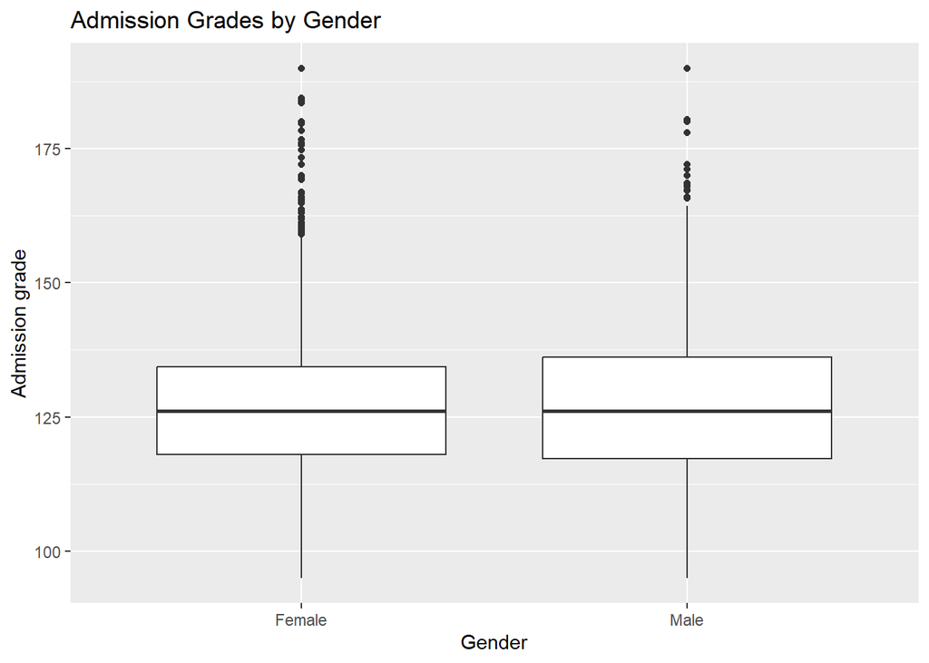

```r
StudentDataset %>%
    ggplot(aes(x=Gender, y=`Admission grade`)) +
    geom_boxplot() +
    labs(title="Admission Grades by Gender")
```

```r
ggsave('Project 1, Part 1, Figure 1.png')
```

It seems interesting that the medians of the two genders are rather close. We shall now administer a $t$-test.

```r
t.test(`Admission grade`~Gender, data=StudentDataset)
```

```
##
##  Welch Two Sample t-test
##
## data:  Admission grade by Gender
## t = -0.5412, df = 2999, p-value = 0.5884
## alternative hypothesis: true difference in means between group Female and group Male is not equal to 0
## 95 percent confidence interval:
##  -1.1656588  0.6613672
## sample estimates:
## mean in group Female   mean in group Male
##             126.8894             127.1416
```

We see that $p = 0.5884 > \alpha$. This means we can *accept* the null hypothesis: that *there is no significant difference* in admission grade between the two genders.

Now, let us investigate whether `International` would make any difference.

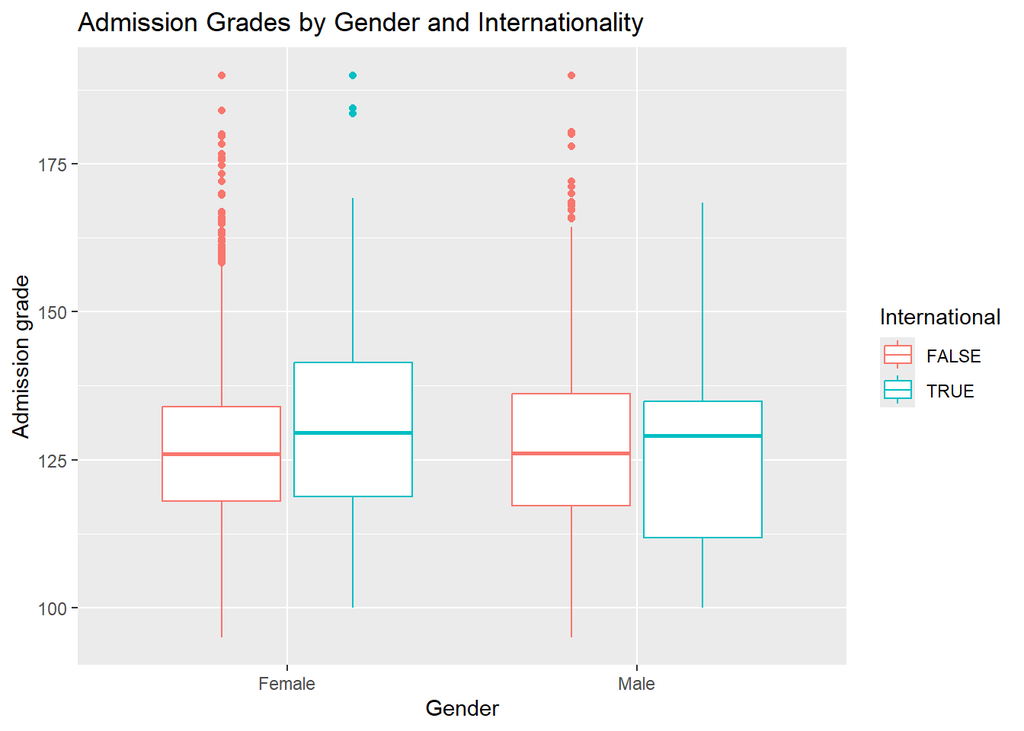

```r
StudentDataset %>%
    ggplot(aes(x=Gender, y=`Admission grade`, colour=International)) +
    geom_boxplot() +
    labs(title="Admission Grades by Gender and Internationality")
```

```r
ggsave('Project 1, Part 1, Figure 2.png')
```

We see that some things have changed: There seems to be some difference between non-international female students and international female students, and between non-international male students and international male students. For both of these cases, let us use the $t$-test.

```r
FemaleDataset <- filter(StudentDataset, Gender=="Female")
t.test(`Admission grade`~International, data=FemaleDataset)
```

```
##
##  Welch Two Sample t-test
##
## data:  Admission grade by International
## t = -1.6652, df = 81.026, p-value = 0.09973
## alternative hypothesis: true difference in means between group FALSE and group TRUE is not equal to 0
## 95 percent confidence interval:
##  -8.5471706  0.7587918
## sample estimates:
## mean in group FALSE  mean in group TRUE
##            126.7808            130.6750
```

We see that $p = 0.09973 > \alpha$, so there is no significant difference in admission grade between non-international female students and international female students. This is despite the fact that the median grades of non-international female students is lower than those of the international female students. However, this $p$ value still makes sense because of how close the means of the two groups are.

```r
MaleDataset <- filter(StudentDataset, Gender=="Male")
t.test(`Admission grade`~International, data=MaleDataset)
```

```
##
##  Welch Two Sample t-test
##
## data:  Admission grade by International
## t = 0.49691, df = 29.802, p-value = 0.6229
## alternative hypothesis: true difference in means between group FALSE and group TRUE is not equal to 0
## 95 percent confidence interval:
##  -5.133548  8.433670
## sample estimates:
## mean in group FALSE  mean in group TRUE
##            127.1734            125.5233
```

We see that $p = 0.6229 > \alpha$, so there is no significant difference in admission grade between non-international male students and international male students. Again, this is despite the fact that the median grade of non-international male students is lower than those of the international male students. However, this $p$ value still makes sense because of how close the means of the two groups are (in fact, much closer than the means between female students).

### In Relation to Whether a Student Holds a Scholarship

We aim to see if there is a difference in `Admission grade` in terms of `Scholarship holder`. Similar to `Gender`, `Scholarship holder` is also a binary variable – with only two choices `TRUE` and `FALSE`, so appropriate tests shall be utilised.

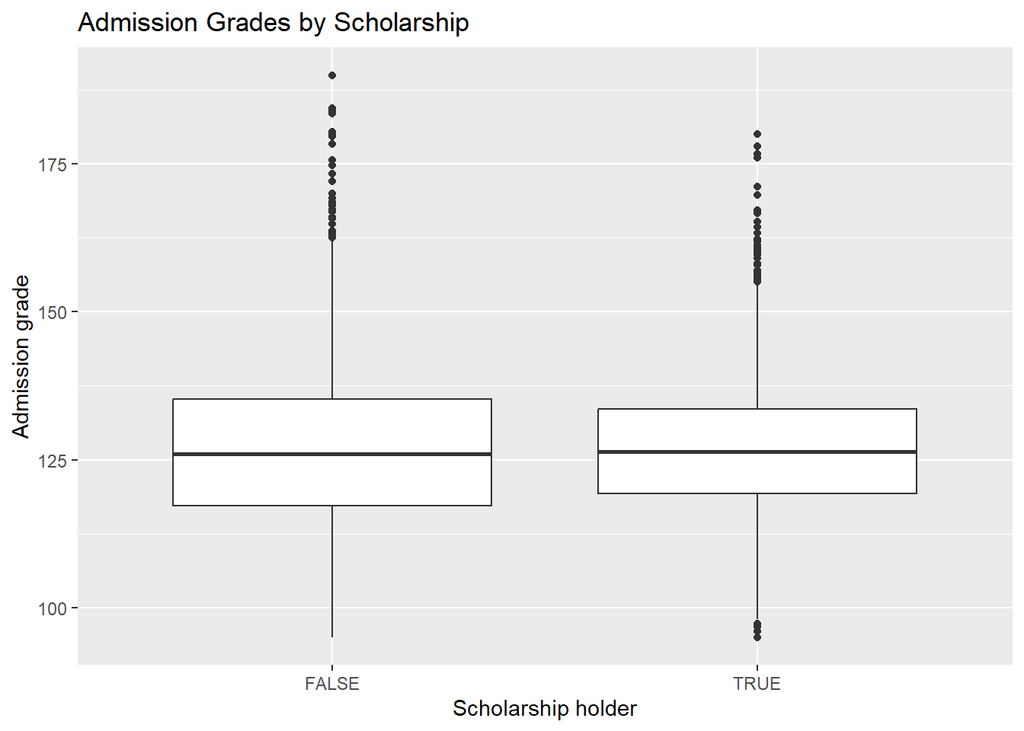

```r
StudentDataset %>%
    ggplot(aes(x=`Scholarship holder`, y=`Admission grade`)) +
    geom_boxplot() +
    labs(title="Admission Grades by Scholarship")
```

```r
ggsave('Project 1, Part 1, Figure 3.png')
```

We shall now administer a $t$-test.

```r
t.test(`Admission grade`~`Scholarship holder`, data=StudentDataset)
```

```
##
##  Welch Two Sample t-test
##
## data:  Admission grade by Scholarship holder
## t = -1.3322, df = 2087.9, p-value = 0.183
## alternative hypothesis: true difference in means between group FALSE and group TRUE is not equal to 0
## 95 percent confidence interval:
##  -1.5642453  0.2987397
## sample estimates:
## mean in group FALSE  mean in group TRUE
##            126.8209            127.4537
```

We see that $p = 0.183 > \alpha$. This means we can *accept* the null hypothesis: that *there is no significant difference* in admission grade whether a student has a scholarship.

Now, let us investigate whether `International` would make any difference.

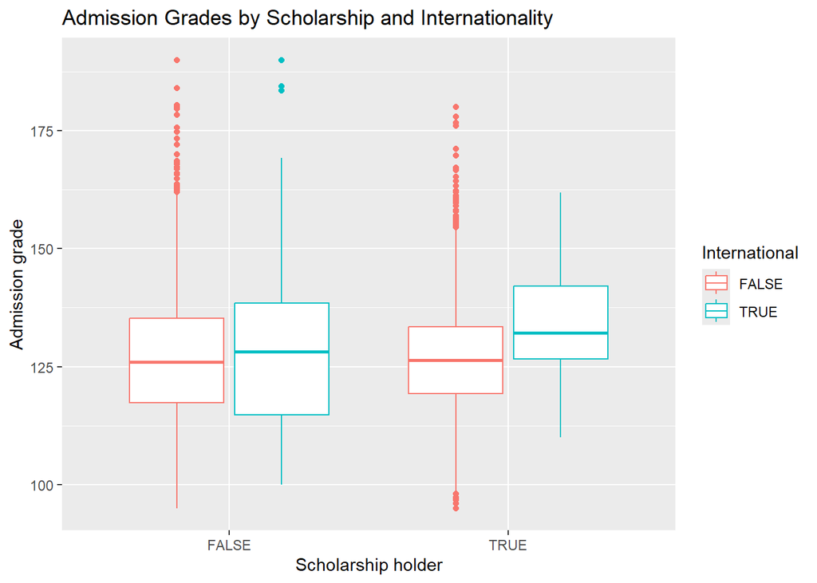

```r
StudentDataset %>%
    ggplot(aes(x=`Scholarship holder`, y=`Admission grade`, colour=International)) +
    geom_boxplot() +
    labs(title="Admission Grades by Scholarship and Internationality")
```

```r
ggsave('Project 1, Part 1, Figure 4.png')
```

Like before, we see that some things have changed: There seems to be some difference between non-international scholarship non-holders and international scholarship non-holders, and between non-international scholarship holders and international scholarship holders. For both of these cases, let us use the $t$-test.

```r
NoScholatshipDataset <- filter(StudentDataset, `Scholarship holder`==FALSE)
t.test(`Admission grade`~International, data=NoScholatshipDataset)
```

```
##
##  Welch Two Sample t-test
##
## data:  Admission grade by International
## t = -0.59304, df = 92.466, p-value = 0.5546
## alternative hypothesis: true difference in means between group FALSE and group TRUE is not equal to 0
## 95 percent confidence interval:
##  -5.738560  3.099404
## sample estimates:
## mean in group FALSE  mean in group TRUE
##            126.7848            128.1044
```

We see that $p = 0.5546 > \alpha$, so there is *no* difference in admission grades between non-international scholarship non-holders and international scholarship non-holders. This makes sense (probably even more so than between genders) because of how the their interquartile ranges overlap almost entirely. However, look at the $t$-test result for scholarship holders:

```r
ScholatshipDataset <- filter(StudentDataset, `Scholarship holder`==TRUE)
t.test(`Admission grade`~International, data=ScholatshipDataset)
```

```
##
##  Welch Two Sample t-test
##
## data:  Admission grade by International
## t = -2.3521, df = 18.579, p-value = 0.02987
## alternative hypothesis: true difference in means between group FALSE and group TRUE is not equal to 0
## 95 percent confidence interval:
##  -14.2393465  -0.8188796
## sample estimates:
## mean in group FALSE  mean in group TRUE
##            127.3235            134.8526
```

We see that $p = 0.02987 < \alpha$, so *there is a difference* in admission grades between non-international scholarship holders and international scholarship holders, which correspond to how their interquartile ranges of the two variables mostly do not overlap.

## *Part 2.* Grades in 1st and 2nd Semesters

We aim to see if there is a correlation between `Curricular units 1st sem (grade)` and `Curricular units 2nd sem (grade)`, both of which are numerical variables. We shall start by simply plotting these variables.

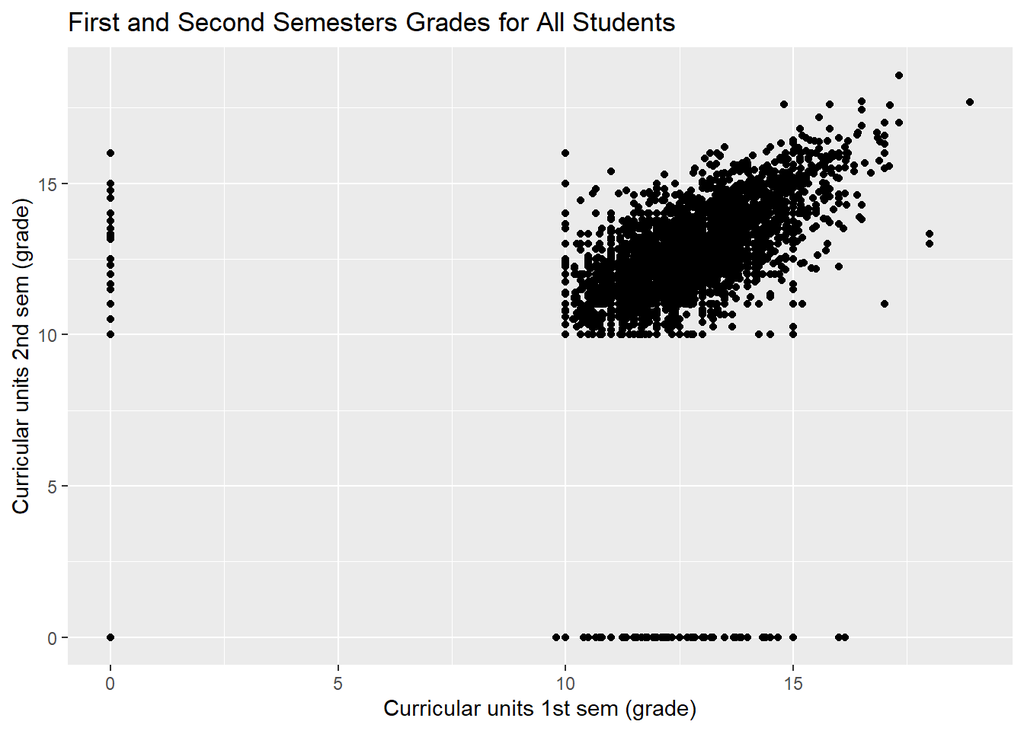

```r
StudentDataset %>%
    ggplot(aes(x=`Curricular units 1st sem (grade)`,
               y=`Curricular units 2nd sem (grade)`)) +
    geom_point() +
    labs(title="First and Second Semesters Grades for All Students")
```

```r
ggsave('Project 1, Part 2, Figure 1.png')
```

We can see that there are many outliers (namely those `0` grades); for the sake of simplicity, those entries will be removed. To aid what we’re about to do later, let us also put a linear regression line.

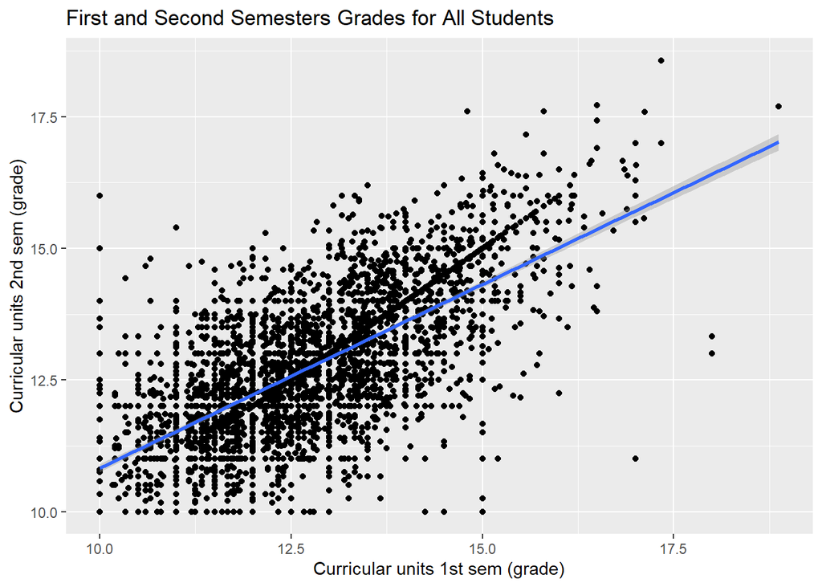

```r
NoZeroGradeDataset <- StudentDataset %>%
    filter(`Curricular units 1st sem (grade)` >= 10,
           `Curricular units 2nd sem (grade)` >= 10)

NoZeroGradeDataset %>%
    ggplot(aes(x=`Curricular units 1st sem (grade)`,
               y=`Curricular units 2nd sem (grade)`)) +
    geom_point() +
    geom_smooth(method="lm") +
    labs(title="First and Second Semesters Grades for All Students")
```

```r
ggsave('Project 1, Part 2, Figure 2.png')
```

Much better! Though, I find it funny how the regression line actually does not rest on the diagonal $y=x$ axis where many of the points line up. Now let us analyse this (filtered) dataset by checking its linear model and correlation coefficients.

```r
GradeLM <- lm(`Curricular units 2nd sem (grade)`~`Curricular units 1st sem (grade)`,
              data=NoZeroGradeDataset)
summary(GradeLM)
```

```
##
## Call:
## lm(formula = `Curricular units 2nd sem (grade)` ~ `Curricular units 1st sem (grade)`,
##     data = NoZeroGradeDataset)
##
## Residuals:
##     Min      1Q  Median      3Q     Max
## -4.7117 -0.6546  0.0192  0.5943  5.1730
##
## Coefficients:
##                                    Estimate Std. Error t value Pr(>|t|)
## (Intercept)                         3.84892    0.16466   23.38   <2e-16 ***
## `Curricular units 1st sem (grade)`  0.69781    0.01285   54.32   <2e-16 ***
## ---
## Signif. codes:  0 '***' 0.001 '**' 0.01 '*' 0.05 '.' 0.1 ' ' 1
##
## Residual standard error: 1.011 on 3510 degrees of freedom
## Multiple R-squared:  0.4567, Adjusted R-squared:  0.4566
## F-statistic:  2951 on 1 and 3510 DF,  p-value: < 2.2e-16
```

We see that $p = 2.2 \cdot 10^{-16}$, so the null hypothesis is *rejected* and there exists a non-zero linear slope in the linear model. Though, we also see that the residual standard error is $1.011$ and $R^2 = 0.4566$ (so about $45%$ of variability in `Curricular units 2nd sem (grade)` is explained by the model); that’s not exactly terrible, but it’s not that good, either. The linear regression line is
$$Y = 3.84892 + 0.69781 X + \varepsilon$$
meaning for every 1 point increase in `Curricular units 1st sem (grade)`, `Curricular units 2nd sem (grade)` increases $0.69781$ points.

We check for correlation:

```r
cor.test(NoZeroGradeDataset$`Curricular units 1st sem (grade)`,
         NoZeroGradeDataset$`Curricular units 2nd sem (grade)`)
```

```
##
##  Pearson's product-moment correlation
##
## data:  NoZeroGradeDataset$`Curricular units 1st sem (grade)` and NoZeroGradeDataset$`Curricular units 2nd sem (grade)`
## t = 54.324, df = 3510, p-value < 2.2e-16
## alternative hypothesis: true correlation is not equal to 0
## 95 percent confidence interval:
##  0.6574517 0.6934057
## sample estimates:
##       cor
## 0.6758306
```

```r
cor.test(NoZeroGradeDataset$`Curricular units 1st sem (grade)`,
         NoZeroGradeDataset$`Curricular units 2nd sem (grade)`,
         method='spearman')
```

```
##
##  Spearman's rank correlation rho
##
## data:  NoZeroGradeDataset$`Curricular units 1st sem (grade)` and NoZeroGradeDataset$`Curricular units 2nd sem (grade)`
## S = 2440254355, p-value < 2.2e-16
## alternative hypothesis: true rho is not equal to 0
## sample estimates:
##       rho
## 0.6619952
```

Pearson’s method returns $0.6758306$, and Spearman’s method returns $\rho = 0.6619952$, so the correlation is moderate.

Now, let us break the data down by `Target`. We shall use the same process as we did earlier.

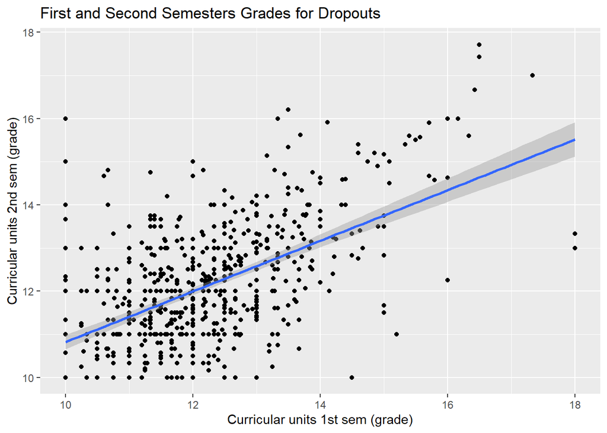

```r
DropoutDataset <- filter(NoZeroGradeDataset, Target=="Dropout")

DropoutDataset %>%
    ggplot(aes(x=`Curricular units 1st sem (grade)`,
               y=`Curricular units 2nd sem (grade)`)) +
    geom_point() +
    geom_smooth(method="lm") +
    labs(title="First and Second Semesters Grades for Dropouts")
```

```r
ggsave('Project 1, Part 2, Figure 3.png')
DropoutLM <- lm(`Curricular units 2nd sem (grade)`~`Curricular units 1st sem (grade)`,
                data=DropoutDataset)
summary(DropoutLM)
```

```
##
## Call:
## lm(formula = `Curricular units 2nd sem (grade)` ~ `Curricular units 1st sem (grade)`,
##     data = DropoutDataset)
##
## Residuals:
##     Min      1Q  Median      3Q     Max
## -3.4599 -0.7978 -0.0856  0.7126  5.1799
##
## Coefficients:
##                                    Estimate Std. Error t value Pr(>|t|)
## (Intercept)                         4.95398    0.41733   11.87   <2e-16 ***
## `Curricular units 1st sem (grade)`  0.58662    0.03407   17.22   <2e-16 ***
## ---
## Signif. codes:  0 '***' 0.001 '**' 0.01 '*' 0.05 '.' 0.1 ' ' 1
##
## Residual standard error: 1.161 on 668 degrees of freedom
## Multiple R-squared:  0.3074, Adjusted R-squared:  0.3064
## F-statistic: 296.5 on 1 and 668 DF,  p-value: < 2.2e-16
```

```r
cor.test(DropoutDataset$`Curricular units 1st sem (grade)`,
         DropoutDataset$`Curricular units 2nd sem (grade)`)
```

```
##
##  Pearson's product-moment correlation
##
## data:  DropoutDataset$`Curricular units 1st sem (grade)` and DropoutDataset$`Curricular units 2nd sem (grade)`
## t = 17.22, df = 668, p-value < 2.2e-16
## alternative hypothesis: true correlation is not equal to 0
## 95 percent confidence interval:
##  0.4997157 0.6048166
## sample estimates:
##       cor
## 0.5544732
```

```r
cor.test(DropoutDataset$`Curricular units 1st sem (grade)`,
         DropoutDataset$`Curricular units 2nd sem (grade)`,
         method='spearman')
```

```
##
##  Spearman's rank correlation rho
##
## data:  DropoutDataset$`Curricular units 1st sem (grade)` and DropoutDataset$`Curricular units 2nd sem (grade)`
## S = 26314058, p-value < 2.2e-16
## alternative hypothesis: true rho is not equal to 0
## sample estimates:
##       rho
## 0.4750528
```

For dropouts, we can see that $p < 2.2 \cdot 10^{-16} < \alpha$, so the null hypothesis is rejected and there exists a non-zero linear slope in the linear model. The residual standard error is $1.161$, and $R^2 = 0.3074$, so this linear model is a little worse than the `GradeLM` model. The regression line is
$$Y = 4.95398 + 0.58662 X
+ \varepsilon$$
meaning for every 1 point increase in `Curricular units 1st sem (grade)`, `Curricular units 2nd sem (grade)` increases $0.58662$ points. As for correlation, Pearson’s method returns $0.5544732$, and Spearman’s method returns $\rho = 0.4750528$, so the correlation here is a bit worse than that of the `GradeLM` model.

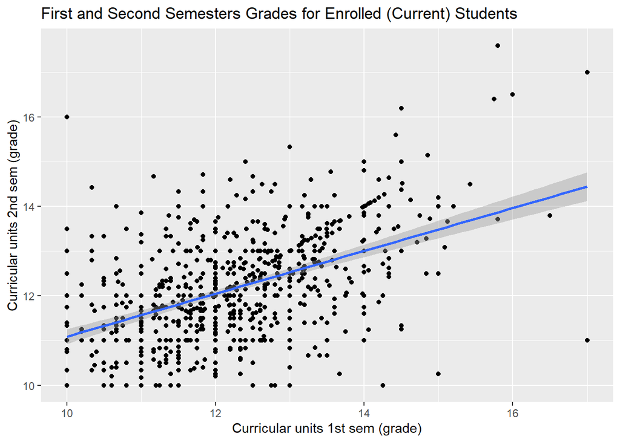

```r
EnrolledDataset <- filter(NoZeroGradeDataset, Target=="Enrolled")

EnrolledDataset %>%
    ggplot(aes(x=`Curricular units 1st sem (grade)`,
               y=`Curricular units 2nd sem (grade)`)) +
    geom_point() +
    geom_smooth(method="lm") +
    labs(title="First and Second Semesters Grades for Enrolled (Current) Students")
```

```r
ggsave('Project 1, Part 2, Figure 4.png')
EnrolledLM <- lm(`Curricular units 2nd sem (grade)`~`Curricular units 1st sem (grade)`,
                 data=EnrolledDataset)
summary(EnrolledLM)
```

```
##
## Call:
## lm(formula = `Curricular units 2nd sem (grade)` ~ `Curricular units 1st sem (grade)`,
##     data = EnrolledDataset)
##
## Residuals:
##     Min      1Q  Median      3Q     Max
## -3.4447 -0.7269 -0.0378  0.6159  4.9092
##
## Coefficients:
##                                    Estimate Std. Error t value Pr(>|t|)
## (Intercept)                         6.29948    0.40606   15.51   <2e-16 ***
## `Curricular units 1st sem (grade)`  0.47913    0.03303   14.51   <2e-16 ***
## ---
## Signif. codes:  0 '***' 0.001 '**' 0.01 '*' 0.05 '.' 0.1 ' ' 1
##
## Residual standard error: 1.064 on 708 degrees of freedom
## Multiple R-squared:  0.2291, Adjusted R-squared:  0.228
## F-statistic: 210.4 on 1 and 708 DF,  p-value: < 2.2e-16
```

```r
cor.test(EnrolledDataset$`Curricular units 1st sem (grade)`,
         EnrolledDataset$`Curricular units 2nd sem (grade)`)
```

```
##
##  Pearson's product-moment correlation
##
## data:  EnrolledDataset$`Curricular units 1st sem (grade)` and EnrolledDataset$`Curricular units 2nd sem (grade)`
## t = 14.507, df = 708, p-value < 2.2e-16
## alternative hypothesis: true correlation is not equal to 0
## 95 percent confidence interval:
##  0.4198858 0.5334660
## sample estimates:
##       cor
## 0.4786761
```

```r
cor.test(EnrolledDataset$`Curricular units 1st sem (grade)`,
         EnrolledDataset$`Curricular units 2nd sem (grade)`,
         method='spearman')
```

```
##
##  Spearman's rank correlation rho
##
## data:  EnrolledDataset$`Curricular units 1st sem (grade)` and EnrolledDataset$`Curricular units 2nd sem (grade)`
## S = 32603226, p-value < 2.2e-16
## alternative hypothesis: true rho is not equal to 0
## sample estimates:
##       rho
## 0.4534403
```

For current enrolled students (I think that’s what `Enrolled` means), we can see that $p < 2.2 \cdot 10^{-16} < \alpha$, so the null hypothesis is rejected and there exists a non-zero linear slope in the linear model. The residual standard error is $1.064$, and $R^2 = 0.2291$, so this linear model is actually even worse than the `DropoutLM` model. The regression line is
$$Y = 6.29948 + 0.47913 X
+ \varepsilon$$
meaning for every 1 point increase in `Curricular units 1st sem (grade)`, `Curricular units 2nd sem (grade)` increases $0.47913$ points. As for correlation, Pearson’s method returns $0.4786761$, and Spearman’s method returns $\rho = 0.4534403$, so the correlation here is a bit worse than that of the `GradeLM` model but roughly the same as `DropoutLM` in terms of correlation.

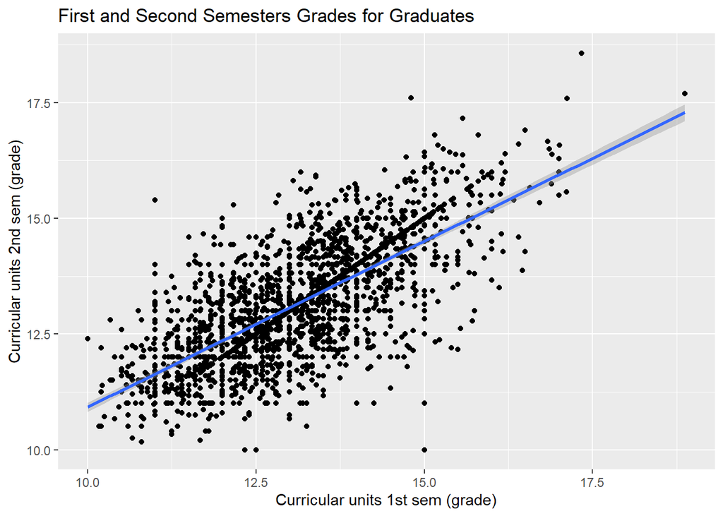

```r
GraduateDataset <- filter(NoZeroGradeDataset, Target=="Graduate")

GraduateDataset %>%
    ggplot(aes(x=`Curricular units 1st sem (grade)`,
               y=`Curricular units 2nd sem (grade)`)) +
    geom_point() +
    geom_smooth(method="lm") +
    labs(title="First and Second Semesters Grades for Graduates")
```

```r
ggsave('Project 1, Part 2, Figure 5.png')
GraduateLM <- lm(`Curricular units 2nd sem (grade)`~`Curricular units 1st sem (grade)`,
                 data=GraduateDataset)
summary(GraduateLM)
```

```
##
## Call:
## lm(formula = `Curricular units 2nd sem (grade)` ~ `Curricular units 1st sem (grade)`,
##     data = GraduateDataset)
##
## Residuals:
##     Min      1Q  Median      3Q     Max
## -4.5057 -0.5474  0.0042  0.5024  3.7622
##
## Coefficients:
##                                    Estimate Std. Error t value Pr(>|t|)
## (Intercept)                         3.75088    0.20343   18.44   <2e-16 ***
## `Curricular units 1st sem (grade)`  0.71699    0.01546   46.38   <2e-16 ***
## ---
## Signif. codes:  0 '***' 0.001 '**' 0.01 '*' 0.05 '.' 0.1 ' ' 1
##
## Residual standard error: 0.8921 on 2130 degrees of freedom
## Multiple R-squared:  0.5025, Adjusted R-squared:  0.5023
## F-statistic:  2151 on 1 and 2130 DF,  p-value: < 2.2e-16
```

```r
cor.test(GraduateDataset$`Curricular units 1st sem (grade)`,
         GraduateDataset$`Curricular units 2nd sem (grade)`)
```

```
##
##  Pearson's product-moment correlation
##
## data:  GraduateDataset$`Curricular units 1st sem (grade)` and GraduateDataset$`Curricular units 2nd sem (grade)`
## t = 46.382, df = 2130, p-value < 2.2e-16
## alternative hypothesis: true correlation is not equal to 0
## 95 percent confidence interval:
##  0.6870909 0.7293697
## sample estimates:
##       cor
## 0.7088665
```

```r
cor.test(GraduateDataset$`Curricular units 1st sem (grade)`,
         GraduateDataset$`Curricular units 2nd sem (grade)`,
         method='spearman')
```

```
##
##  Spearman's rank correlation rho
##
## data:  GraduateDataset$`Curricular units 1st sem (grade)` and GraduateDataset$`Curricular units 2nd sem (grade)`
## S = 495081857, p-value < 2.2e-16
## alternative hypothesis: true rho is not equal to 0
## sample estimates:
##       rho
## 0.6934744
```

For graduates, we can see that $p < 2.2 \cdot 10^{-16} < \alpha$, so the null hypothesis is rejected and there exists a non-zero linear slope in the linear model. The residual standard error is $0.8921$, and $R^2 = 0.5025$, so this linear model is actually a tad better than the `GradeLM` model. The regression line is
$$Y = 3.75088 + 0.71699 X
+ \varepsilon$$
meaning for every 1 point increase in `Curricular units 1st sem (grade)`, `Curricular units 2nd sem (grade)` increases $0.71699$ points. As for correlation, Pearson’s method returns $0.7088665$, and Spearman’s method returns $\rho = 0.6934744$, so the correlation here is actaully better than that of the `GradeLM` model.